# Oooh, shiny!

12 November 2015

## Teaching linear models

### In three lectures

## A unique cohort

- I teach second year vet students biostatistics.
- Vet students are smart and hard working.
- They spend a lot of time together so know each other well.
- Most just want to know the **how**, but some want the **why**.
- Goal: Cover multiple regression and analysis of variance using R.

## Time and content split

- 150 minutes of lectures and 360 minutes of labs.
- Lectures are there to reinforce what they've learnt in labs, and explain concepts.
- Summary notes supply more detail.

## Topics covered

| Session | Topics |
| --- | --- |
| Lab | RStudio, EDA (scatter plots), simple linear regression. |
| Lecture | Least squares, model assumptions, diagnostics. |
| Lab | Multiple linear regression. |
| Lecture | Multiple linear regression, F-test, factorial models. |
| Lab | Factorial models. |
| Lecture | Additive models, interactions |
| Lab | Interactions, mixed models. |

## Labs

- Use RStudio exclusively.
- Have ~50 students per group (STB2).
- Two postgrads as helpers (thanks Khair + Penny!)

## The R stumbling block

- Supply example code (decreasing in later labs).
- Teach students to produce reports from a script.
  - encourages scripting rather than interactive R.
  - encourages reproducible research.
  - saves them time on their assignment.
- Constantly encourage documentation.

## Creating notebooks from R scripts

- 'Compile Notebook' button in RStudio invokes `knitr::spin`.
- Roxygen comments starting `#'` in an R script are treated as narrative text.
- Can include markdown for formatting.
- R code is placed in-line, as is any output (text/plots).
- Results in an HTML or Word document (.docx). Familiarity helps!

## Example

## Lectures

- Can spend a lot of time preparing lectures.
- Include graphical explanations in preference to the maths where possible.
- Include interactives that allow students to explore concepts during lecture.

## Tools

## Tools

- RStudio for development.
- Rmarkdown + ioslides for HTML presentation.
- Shiny for interactives.
- Shiny-server for serving up webapps.

## RStudio

- It contains helpful shortcuts.
- Has syntax highlighting.
- Integrates with git for version control.

## Rmarkdown for slides

- Markdown is a (simple) markup language.
- Designed for generating HTML, but can generate Word and PDF.
- Rmarkdown adds R codeblocks into markdown.
- One document to rule them all.

## Work flow

- Rmarkdown is a front-end for **knitr** and **pandoc**.
- knitr processes the R markdown (.Rmd) file, runs R code and converts to plain markdown (.md).
- pandoc then processes the markdown document, turning it into HTML (or Word/PDF via LaTeX).
- Automated by the "Knit HTML" button in RStudio.

## Example

## Ooooh, shiny!

## Interactivity: Shiny

- R package for developing webapps without having to know HTML or javascript.
- Define the user interface in `ui.R`.
- Define what happens on interaction in `server.R`.
- Shiny then generates the HTML, bundles the javascript and calls into R for the execution.

## Incorporating interactives in slides

- The slides are just HTML.
- Can add a shiny app directly in an R codeblock and run it from RStudio.
- Host the shiny app elsewhere, link using an `<iframe>` in a slide, access from a web browser.

## Shiny server

- Webserver package for *nix that links up with R.
- Really easy to deploy into a VM (e.g. using Vagrant).
- If on port 8080, it is viewable on both the Massey wired and wireless networks.
- **Disadvantage**: Not available outside of Massey network at present.

## Examples

## Other interactives: dygraphs

[interactive chart not shown]

## Advantages

- Easy to write slides, but not really easier than any other method.
- Inline R-code is really useful for examples. No need to copy and paste code or output.
- Can incorporate interactives.
- Can produce both HTML or PDF slides for printing.

## Disadvantages

- Layout is somewhat fixed. Themes/colours are available.
- CSS+HTML is pretty powerful for altering things, but is a new language/paradigm to learn.
- Printing. Getting PDF version of slides similar to HTML can take some work.
  - Plot sizes
  - R output size
  - Further restricts layout

## Feedback

## Feedback: Interactives

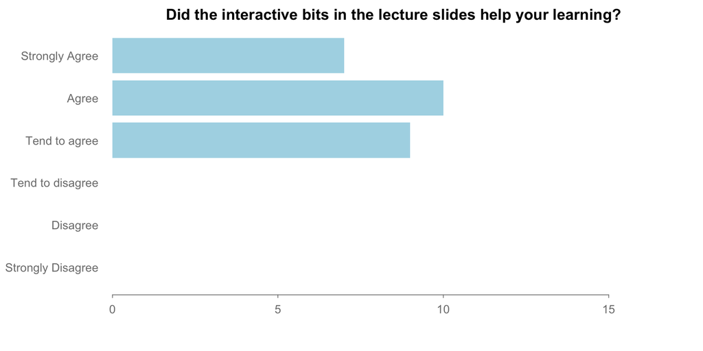

## Feedback: Interactives

It allowed me to understand the connections between the different values and what they actually mean

The interactive bits in the lectures were very helpful to understand some concepts!

wish they worked outside of massey

Very helpful to visualise the maths

I did appreciate it, however I did not actively do them myself. Didn't bother to open in html format at home, just looked at pdf

The interactive bits were helpful.

## Feedback: Compiling notebooks

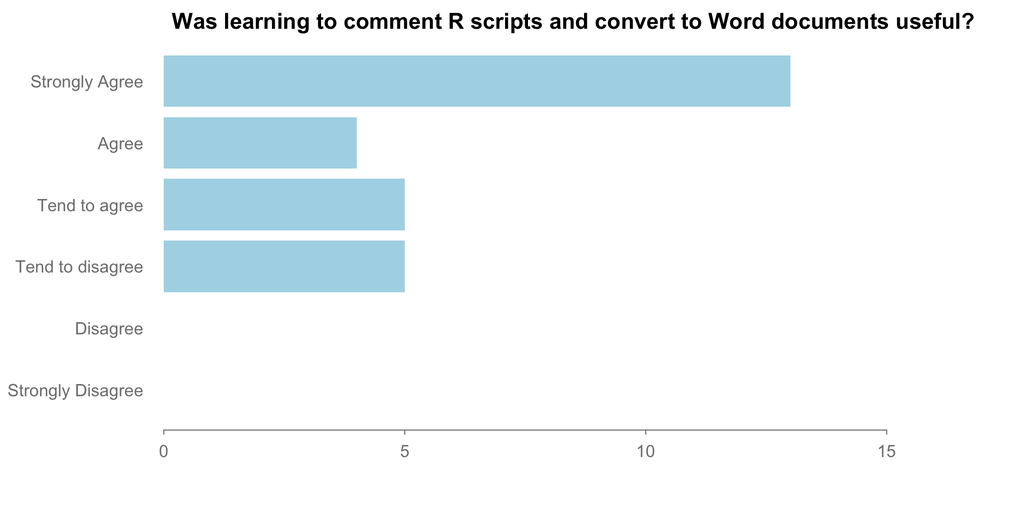

## Feedback: Compiling notebooks

Definitely. Not just for the assignment but for Biostats learning in general. Writing the comments actually encouraged us to think about what we were doing rather than just blindly typing in code.

They could be useful indeed. But I did not use them as I found it easier to simply copy and paste the R outputs into a separate word document

I didn't use it as it wouldn't work on my computer.

Yesss!!! It saved heaps and heaps of time for my assignment.

Massive time saver!

I didn't find it that useful for the assignment but it was useful for making notes relating to the script so when coming back to it after a break i knew what did what.

## Changes for next time

- More interactives for concept motivation.
- Get interactives working outside Massey network.
- Add ratings to interactives for feedback?

Slides: http://bit.ly/1M5PP4O

Twitter: [@jmarshallnz](https://twitter.com/jmarshallnz)

Github: jmarshallnz

**Thanks for listening!**